# lab3a_3.3

## (a)

**How many p-values are in the data set?**

```
## [1] 3170
```

Each entry in this data frame is a p-value.

## (b)

**Generate a histogram of the (unadjusted) Hedenfalk p-values.**

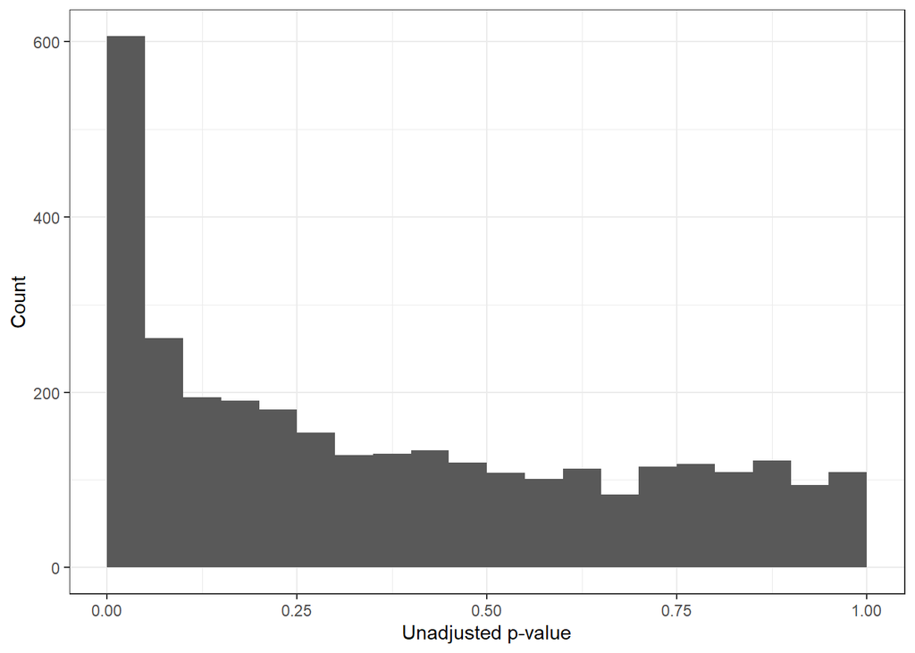

## (c)

**How many (unadjusted) p-values are significant at the 5% level of significance? What proportion of all p-values in the data set is this?**

```
## [1] 0.1908517
```

## (e)

**Using p.adjust() find the Bonferroni and BH p-values. Plot histograms of each and find the number of significant results after adjustment for both.**

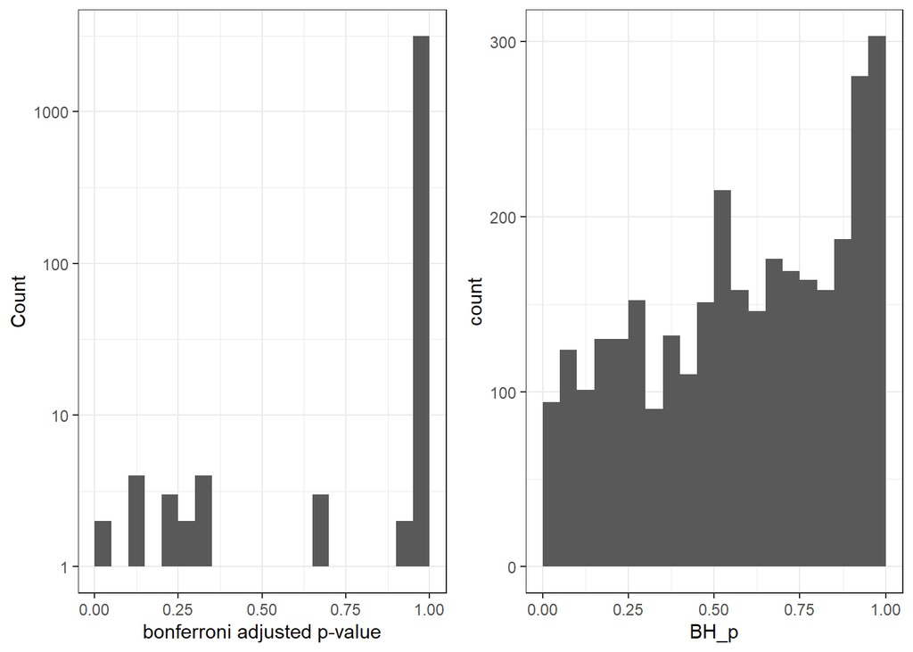

Number of significant p-values and proportion for the Bonferroni method

```
## [1] 2
```

```
## [1] 0.0006309148
```

Number of significant p-values and proportion for the BH method

```
## [1] 94
```

```
## [1] 0.029653
```

## (f)

**Comment on the difference between the Bonferroni method and the BH method.**

Bonferroni method is more conservative and controls the FWER whereas the BH method allows for more false positives and controls the FDR.